# Course Project 1

## Load the data into R using read.csv creating variable “Activity”

```r
Activity <- read.csv("activity.csv")
```

## First question: What is mean total number of steps taken per day?

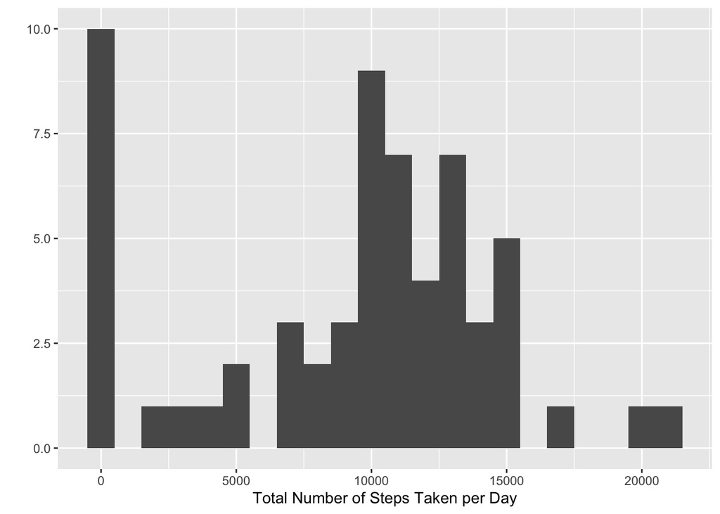

```r
library(ggplot2)
totsteps <- tapply(Activity$steps, Activity$date, FUN = sum, na.rm = TRUE)
qplot(totsteps, binwidth = 1000, xlab = "Total Number of Steps Taken per Day")
```

```r
mean(totsteps, na.rm = TRUE)
```

```
## [1] 9354.23
```

```r
median(totsteps, na.rm = TRUE)
```

```
## [1] 10395
```

## Second question: What is the average daily activity pattern?

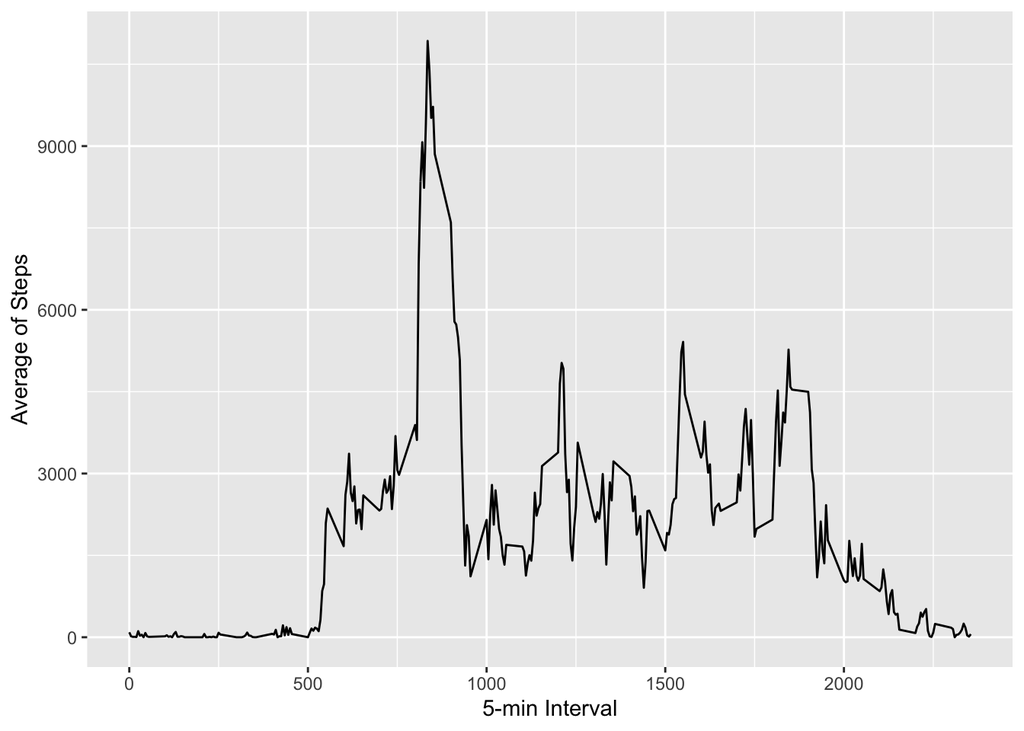

```r
library(ggplot2)
average_daily <- aggregate(x = list(steps = Activity$steps), by = list(interval = Activity$interval), FUN = sum, na.rm = TRUE)
ggplot(data = average_daily, aes(x = interval, y = steps)) +
  geom_line()+
  xlab("5-min Interval") +
  ylab("Average of Steps")
```

Which 5-minute interval, on average across all the days in the dataset, contains the maximum number of steps?

```r
average_daily[which.max(average_daily$steps),]
```

```
##     interval steps
## 104      835 10927
```

## Third question: Imputing missing values

Note that there are a number of days/intervals where there are missing values (coded as NA). The presence of missing days may introduce bias into some calculations or summaries of the data.

```r
miss_values <- is.na(Activity$steps)
table(miss_values)
```

```
## miss_values
## FALSE  TRUE
## 15264  2304
```

```r
# Create a new dataset that is equal to the original dataset but with the missing data filled in.
filling_values <- function(steps, interval) {
  fill <- NA
  if (!is.na(steps))
    fill <- c(steps)
  else
    fill <- (average_daily[average_daily$interval == interval, "steps"])
  return(fill)
}
fill_Activity <- Activity
fill_Activity$steps <- mapply(filling_values, fill_Activity$steps, fill_Activity$interval)
```

Make a histogram of the total number of steps taken each day and, calculate and report the mean and median total number of steps taken per day.

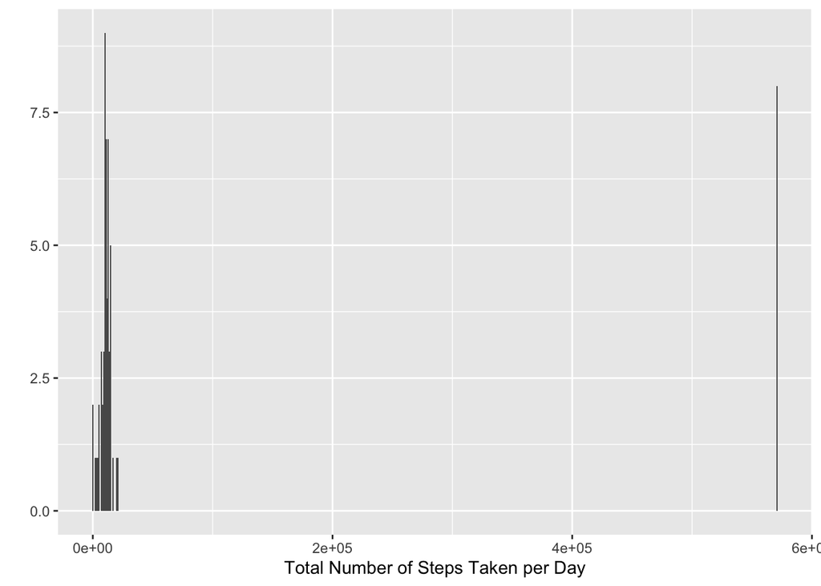

```r
totsteps <- tapply(fill_Activity$steps, fill_Activity$date, FUN = sum)
qplot(totsteps, binwidth = 1000, xlab = "Total Number of Steps Taken per Day")
```

```r
mean(totsteps)
```

```
## [1] 84188.07
```

```r
median(totsteps)
```

```
## [1] 11458
```

## Fourth question: Are there differences in activity patterns between weekdays and weekends?

For this part lets use the weekdays() function to distinguish weekdays from weekends in the dataset; the filled-in missing values dataset will be used for this part: `fill_Activity´.

```r
day.end <- function(date) {
  day <- weekdays(date)
  if (day %in% c("Monday", "Tuesday", "Wednesday", "Thursday", "Friday"))
    return("weekday")
  else if (day %in% c("Saturday", "Sunday"))
    return("weekend")
  else
    stop("invalid date")
}

fill_Activity$date <- as.Date(fill_Activity$date)
fill_Activity$day <- sapply(fill_Activity$date, FUN = day.end)
```

Creating a panel plot containing a time series plot (i.e. type = “l”) of the 5-minute interval (x-axis) and the average number of steps taken, averaged across all weekday days or weekend days (y-axis).

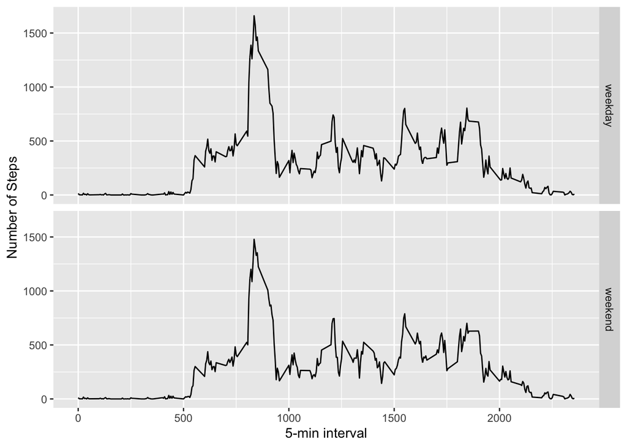

```r
Average <- aggregate(steps ~ interval + day, data = fill_Activity, mean)
ggplot(Average, aes(interval, steps)) + geom_line() + facet_grid(day ~ .) + xlab("5-min interval") + ylab("Number of Steps")
```